# India Adaptation Observation Duplicate IP Address Survey Responses, Retrieval Date 15 April 2024.

Autogenerated data summary from dataMaid

2024-04-21 23:33:30.956906

# Data report overview

The dataset examined has the following dimensions:

| Feature | Result |
| --- | --- |
| Number of observations | 40 |
| Number of variables | 60 |

### Checks performed

The following variable checks were performed, depending on the data type of each variable:

|  | character | factor | labelled | haven labelled | numeric | integer | logical | Date |
| --- | --- | --- | --- | --- | --- | --- | --- | --- |
| Identify miscoded missing values | × | × | × | × | × | × |  | × |
| Identify prefixed and suffixed whitespace | × | × | × | × |  |  |  |  |
| Identify levels with < 6 obs. | × | × | × | × |  |  |  |  |
| Identify case issues | × | × | × | × |  |  |  |  |
| Identify misclassified numeric or integer variables | × | × | × | × |  |  |  |  |
| Identify outliers |  |  |  |  | × | × |  | × |

Please note that all numerical values in the following have been rounded to 2 decimals.

# Summary table

|  | Variable class | # unique values | Missing observations | Any problems? |
| --- | --- | --- | --- | --- |
| start_date | character | 40 | 0.00 % | × |
| end_date | character | 40 | 0.00 % | × |
| status | character | 1 | 0.00 % | × |
| ip_address | character | 20 | 0.00 % | × |
| progress | character | 3 | 0.00 % | × |
| duration_in_seconds | character | 37 | 0.00 % | × |
| finished | character | 2 | 0.00 % | × |
| recorded_date | character | 40 | 0.00 % | × |
| response_id | character | 40 | 0.00 % | × |
| recipient_last_name | character | 1 | 100.00 % | × |
| recipient_first_name | character | 1 | 100.00 % | × |
| recipient_email | character | 1 | 100.00 % | × |
| external_reference | character | 1 | 100.00 % | × |
| location_latitude | numeric | 8 | 5.00 % | × |
| location_longitude | numeric | 8 | 5.00 % | × |
| distribution_channel | character | 1 | 0.00 % | × |
| user_language | character | 7 | 0.00 % | × |
| meta_info_browser | character | 1 | 0.00 % | × |
| meta_info_version | character | 14 | 0.00 % | × |
| meta_info_operating_system | character | 7 | 0.00 % | × |
| meta_info_resolution | character | 19 | 0.00 % | × |
| consent_agreed | character | 1 | 0.00 % | × |
| consent_age | character | 1 | 0.00 % | × |
| consent_cellphone | character | 1 | 0.00 % | × |
| gps_permission | character | 1 | 0.00 % | × |
| household_move | character | 2 | 0.00 % |  |
| flood_year | character | 2 | 0.00 % |  |
| property_loss | character | 3 | 62.50 % | × |
| housing_damage | character | 3 | 62.50 % | × |
| stay_residence | character | 3 | 62.50 % | × |
| flood_close | character | 3 | 37.50 % |  |
| flood_prepared | character | 5 | 0.00 % | × |
| housing_safe | character | 5 | 0.00 % | × |
| climate_problem | character | 5 | 0.00 % | × |
| trust_government | character | 5 | 0.00 % | × |
| enough_eat | character | 2 | 0.00 % | × |
| move_rural_urban | character | 2 | 0.00 % |  |
| contact_authority | character | 2 | 0.00 % |  |
| demo_gender | character | 2 | 0.00 % |  |
| demo_age | character | 23 | 0.00 % | × |
| demo_income | character | 26 | 0.00 % | × |
| comp_phone1_try1 | character | 33 | 0.00 % | × |
| comp_phone1_try2 | character | 32 | 0.00 % | × |
| comp_phone2_try1 | character | 5 | 90.00 % | × |
| comp_phone2_try2 | character | 6 | 87.50 % | × |
| comp_phone3_try1 | character | 3 | 95.00 % | × |
| comp_phone3_try2 | character | 3 | 95.00 % | × |
| geo_lat | character | 21 | 42.50 % | × |
| geo_lng | character | 21 | 42.50 % | × |
| q_url | character | 31 | 0.00 % | × |
| q_language | character | 7 | 0.00 % | × |
| gender | character | 2 | 0.00 % | × |
| region | character | 5 | 0.00 % | × |
| age | character | 3 | 0.00 % |  |
| geo_capability | character | 1 | 100.00 % | × |
| geo_status | character | 3 | 0.00 % | × |
| geo_error | character | 2 | 60.00 % | × |
| country | character | 1 | 100.00 % | × |
| no_surverys_submitted | integer | 1 | 0.00 % | × |
| income_brackets | character | 3 | 0.00 % | × |

# Variable list

## start_date

- The variable is a key (distinct values for each observation).

## end_date

- The variable is a key (distinct values for each observation).

## status

- The variable only takes one (non-missing) value: "IP Address". The variable contains 0 % missing observations.

## ip_address

| Feature | Result |
| --- | --- |
| Variable type | character |
| Number of missing obs. | 0 (0 %) |
| Number of unique values | 20 |
| Mode | “103.85.10.250” |

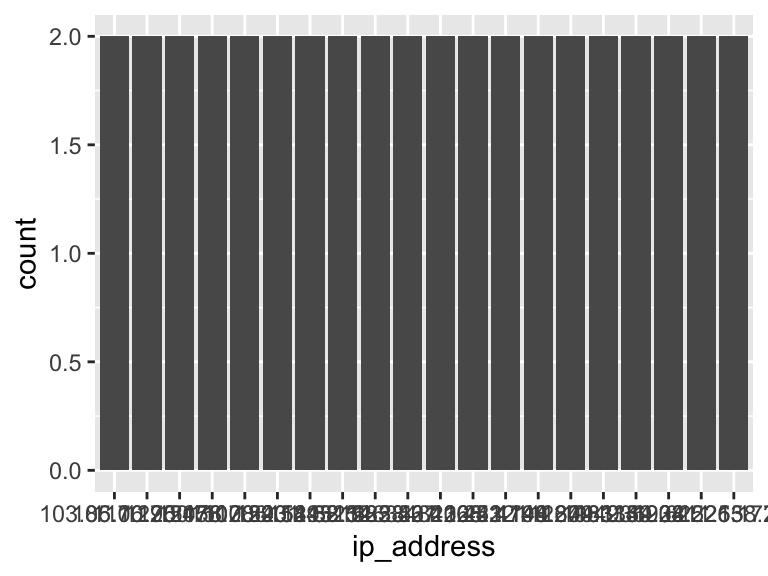

- Note that the following levels have at most five observations: "103.85.10.250", "106.76.90.178", "110.226.176.206", "117.245.108.201", "150.107.243.143", …, "49.204.115.208", "49.33.193.25", "49.34.221.255", "49.34.226.177", "61.1.138.225" (10 values omitted).

## progress

| Feature | Result |
| --- | --- |
| Variable type | character |
| Number of missing obs. | 0 (0 %) |
| Number of unique values | 3 |
| Mode | “100” |

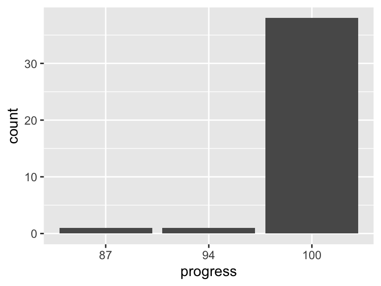

- Note that the following levels have at most five observations: "87", "94".

## duration_in_seconds

| Feature | Result |
| --- | --- |
| Variable type | character |
| Number of missing obs. | 0 (0 %) |
| Number of unique values | 37 |
| Mode | “181” |

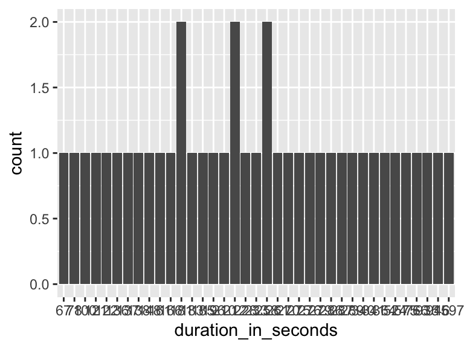

- Note that the following levels have at most five observations: "100", "121", "122", "136", "137", …, "67", "766", "78", "935", "946" (27 values omitted).
- Note: The variable consists exclusively of numbers and takes a lot of different values. Is it perhaps a misclassified numeric variable?

## finished

| Feature | Result |
| --- | --- |
| Variable type | character |
| Number of missing obs. | 0 (0 %) |
| Number of unique values | 2 |
| Mode | “True” |

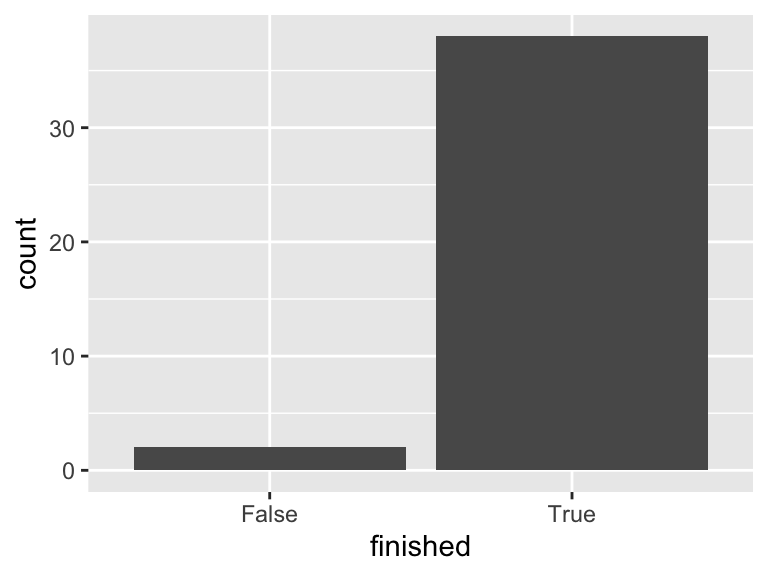

- Note that the following levels have at most five observations: "False".

## recorded_date

- The variable is a key (distinct values for each observation).

## response_id

- The variable is a key (distinct values for each observation).

## recipient_last_name

- The variable only takes one value: "NA".

## recipient_first_name

- The variable only takes one value: "NA".

## recipient_email

- The variable only takes one value: "NA".

## external_reference

- The variable only takes one value: "NA".

## location_latitude

| Feature | Result |
| --- | --- |
| Variable type | numeric |
| Number of missing obs. | 2 (5 %) |
| Number of unique values | 7 |
| Median | 23.03 |
| 1st and 3rd quartiles | 19.94; 23.03 |
| Min. and max. | 12.9; 24.26 |

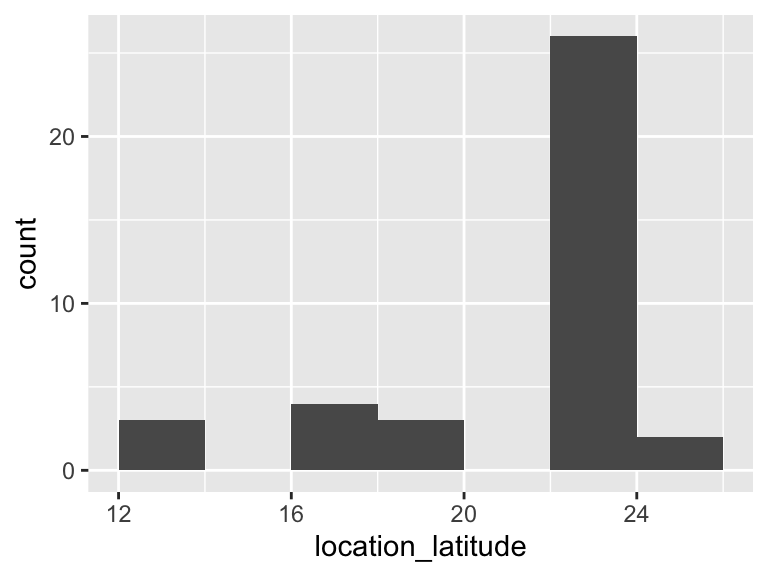

- Note that the following possible outlier values were detected: "24.26".

## location_longitude

| Feature | Result |
| --- | --- |
| Variable type | numeric |
| Number of missing obs. | 2 (5 %) |
| Number of unique values | 7 |
| Median | 72.59 |
| 1st and 3rd quartiles | 72.59; 78.44 |
| Min. and max. | 70.84; 88.38 |

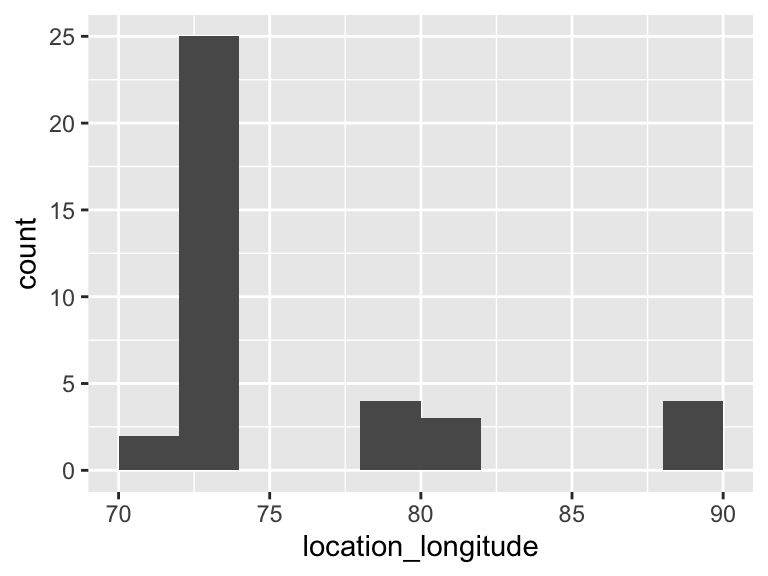

- Note that the following possible outlier values were detected: "70.84", "72.19".

## distribution_channel

- The variable only takes one (non-missing) value: "anonymous". The variable contains 0 % missing observations.

## user_language

| Feature | Result |
| --- | --- |
| Variable type | character |
| Number of missing obs. | 0 (0 %) |
| Number of unique values | 7 |
| Mode | “EN” |

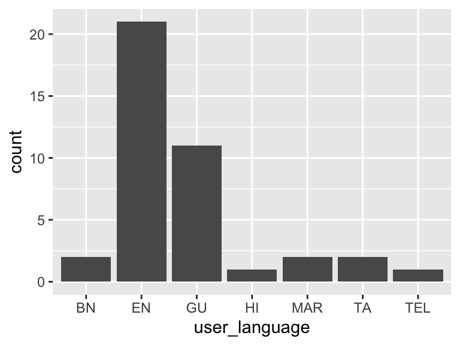

- Note that the following levels have at most five observations: "BN", "HI", "MAR", "TA", "TEL".

## meta_info_browser

- The variable only takes one (non-missing) value: "Chrome". The variable contains 0 % missing observations.

## meta_info_version

| Feature | Result |
| --- | --- |
| Variable type | character |
| Number of missing obs. | 0 (0 %) |
| Number of unique values | 14 |
| Mode | “122.0.6261.119” |

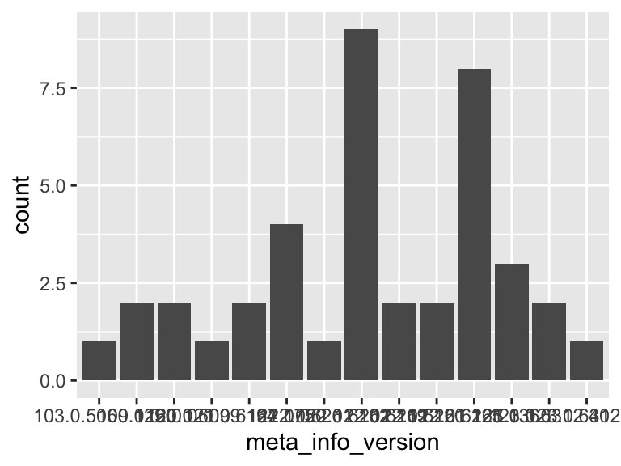

- Note that the following levels have at most five observations: "103.0.5060.129", "109.0.0.0", "116.0.0.0", "120.0.6099.194", "121.0.6167.175", …, "122.0.6261.120", "122.0.6261.125", "123.0.0.0", "123.0.6312.40", "123.0.6312.77" (2 values omitted).

## meta_info_operating_system

| Feature | Result |
| --- | --- |
| Variable type | character |
| Number of missing obs. | 0 (0 %) |
| Number of unique values | 7 |
| Mode | “Android 10” |

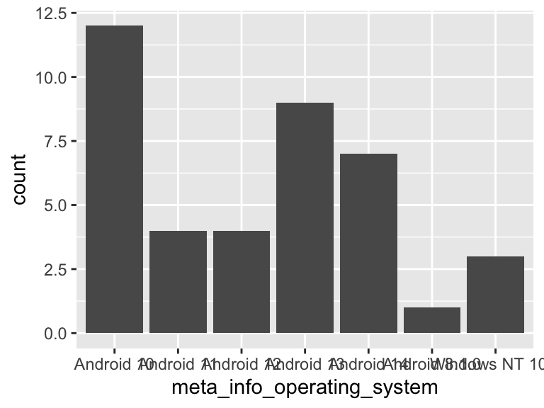

- Note that the following levels have at most five observations: "Android 11", "Android 12", "Android 8.1.0", "Windows NT 10.0".

## meta_info_resolution

| Feature | Result |
| --- | --- |
| Variable type | character |
| Number of missing obs. | 0 (0 %) |
| Number of unique values | 19 |
| Mode | “360x800” |

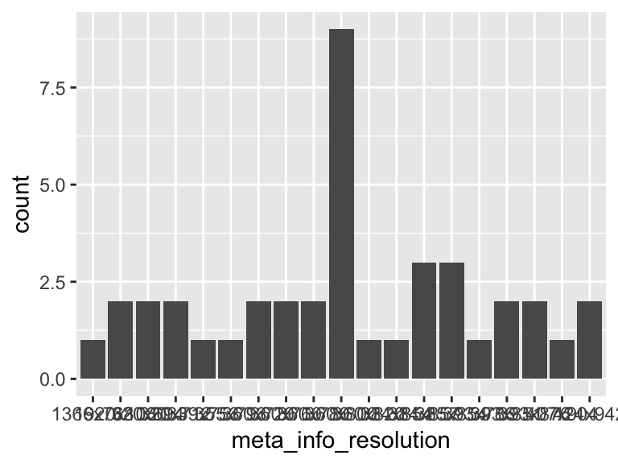

- Note that the following levels have at most five observations: "1366x768", "1920x1080", "320x694", "320x712", "339x753", …, "393x786", "393x851", "393x876", "407x904", "424x942" (8 values omitted).

## consent_agreed

- The variable only takes one (non-missing) value: "I agree to participate". The variable contains 0 % missing observations.

## consent_age

- The variable only takes one (non-missing) value: "Yes". The variable contains 0 % missing observations.

## consent_cellphone

- The variable only takes one (non-missing) value: "Yes". The variable contains 0 % missing observations.

## gps_permission

- The variable only takes one (non-missing) value: "Yes". The variable contains 0 % missing observations.

## household_move

| Feature | Result |
| --- | --- |
| Variable type | character |
| Number of missing obs. | 0 (0 %) |
| Number of unique values | 2 |
| Mode | “No” |

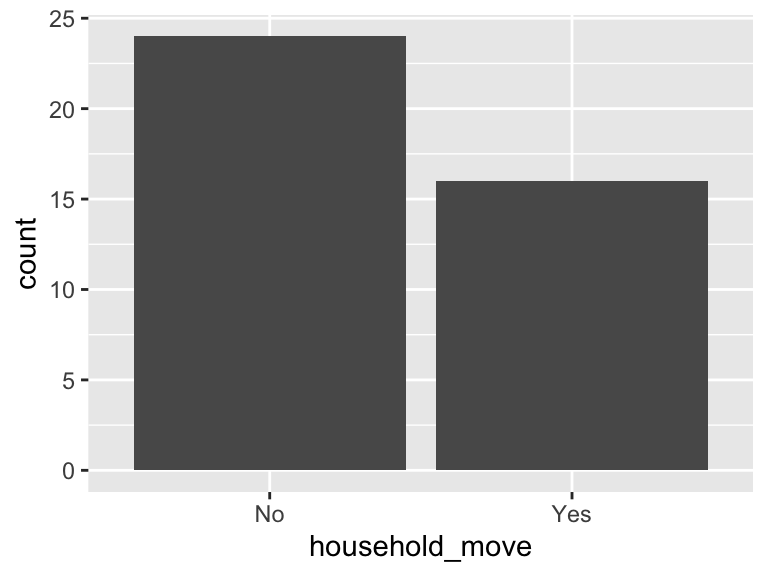

## flood_year

| Feature | Result |
| --- | --- |
| Variable type | character |
| Number of missing obs. | 0 (0 %) |
| Number of unique values | 2 |
| Mode | “No” |

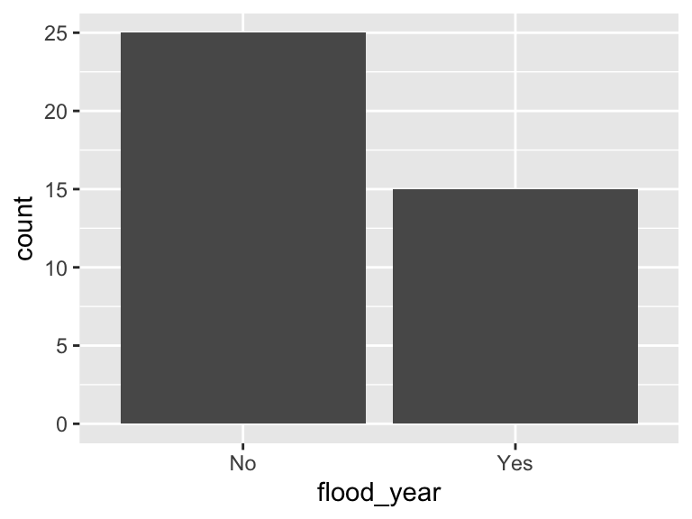

## property_loss

| Feature | Result |
| --- | --- |
| Variable type | character |
| Number of missing obs. | 25 (62.5 %) |
| Number of unique values | 2 |
| Mode | “Yes” |

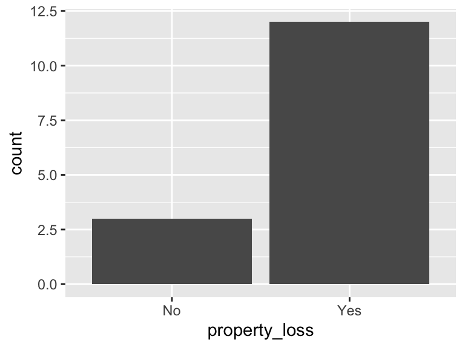

- Note that the following levels have at most five observations: "No".

## housing_damage

| Feature | Result |
| --- | --- |
| Variable type | character |
| Number of missing obs. | 25 (62.5 %) |
| Number of unique values | 2 |
| Mode | “Yes” |

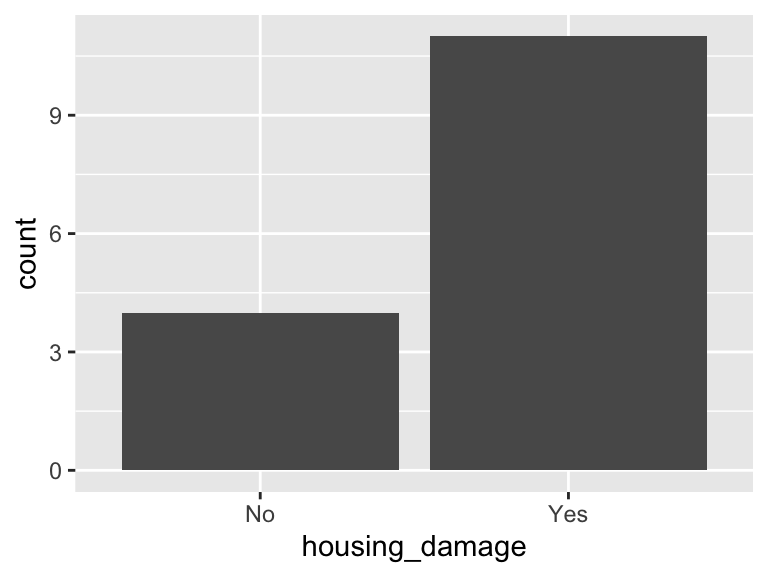

- Note that the following levels have at most five observations: "No".

## stay_residence

| Feature | Result |
| --- | --- |
| Variable type | character |
| Number of missing obs. | 25 (62.5 %) |
| Number of unique values | 2 |
| Mode | “Yes” |

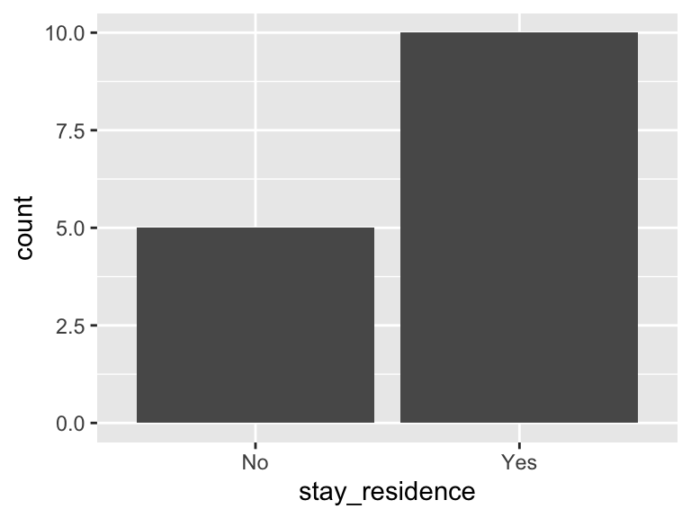

- Note that the following levels have at most five observations: "No".

## flood_close

| Feature | Result |
| --- | --- |
| Variable type | character |
| Number of missing obs. | 15 (37.5 %) |
| Number of unique values | 2 |
| Mode | “No” |

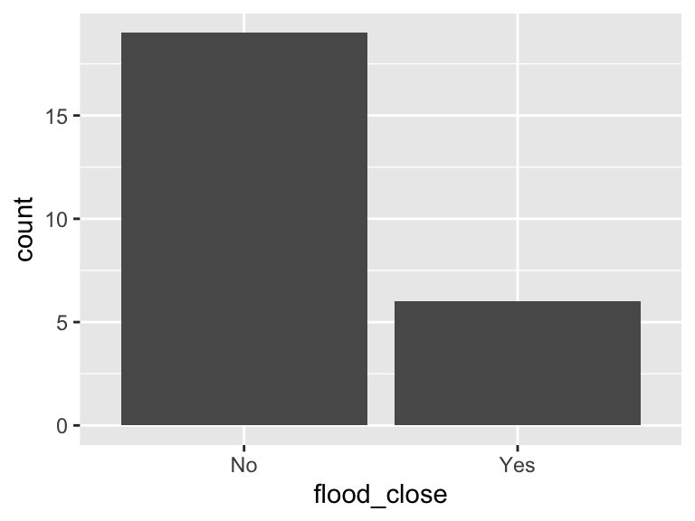

## flood_prepared

| Feature | Result |
| --- | --- |
| Variable type | character |
| Number of missing obs. | 0 (0 %) |
| Number of unique values | 5 |
| Mode | “Strongly agree” |

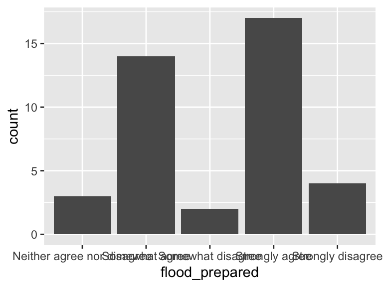

- Note that the following levels have at most five observations: "Neither agree nor disagree", "Somewhat disagree", "Strongly disagree".

## housing_safe

| Feature | Result |
| --- | --- |
| Variable type | character |
| Number of missing obs. | 0 (0 %) |
| Number of unique values | 5 |
| Mode | “Strongly agree” |

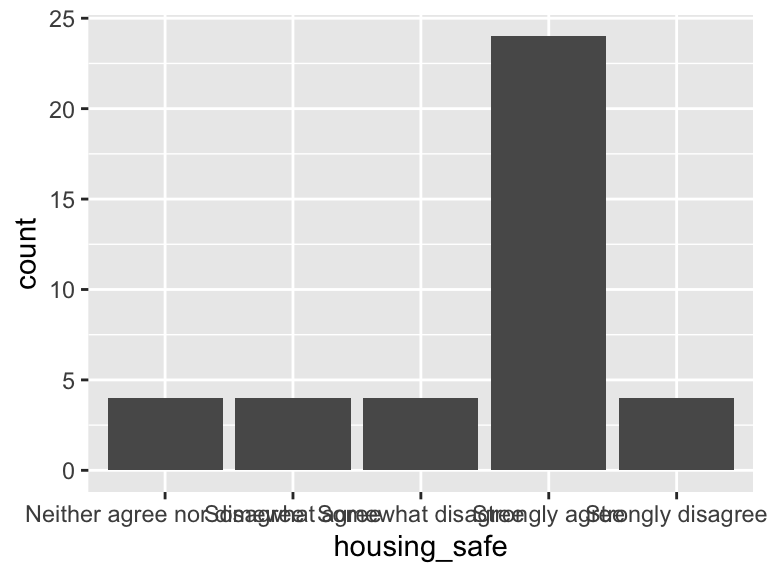

- Note that the following levels have at most five observations: "Neither agree nor disagree", "Somewhat agree", "Somewhat disagree", "Strongly disagree".

## climate_problem

| Feature | Result |
| --- | --- |
| Variable type | character |
| Number of missing obs. | 0 (0 %) |
| Number of unique values | 5 |
| Mode | “Strongly agree” |

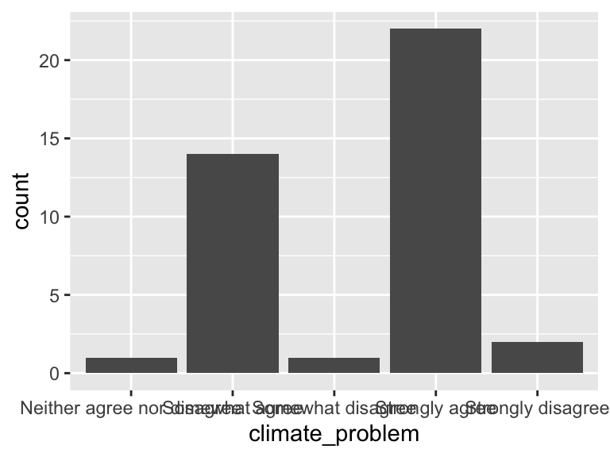

- Note that the following levels have at most five observations: "Neither agree nor disagree", "Somewhat disagree", "Strongly disagree".

## trust_government

| Feature | Result |
| --- | --- |
| Variable type | character |
| Number of missing obs. | 0 (0 %) |
| Number of unique values | 5 |
| Mode | “Strongly agree” |

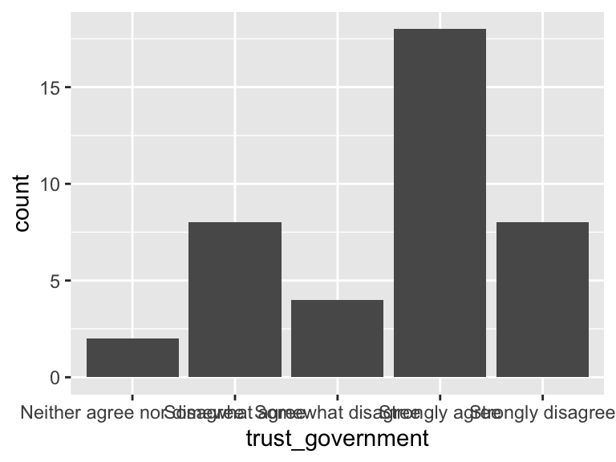

- Note that the following levels have at most five observations: "Neither agree nor disagree", "Somewhat disagree".

## enough_eat

| Feature | Result |
| --- | --- |
| Variable type | character |
| Number of missing obs. | 0 (0 %) |
| Number of unique values | 2 |
| Mode | “Yes” |

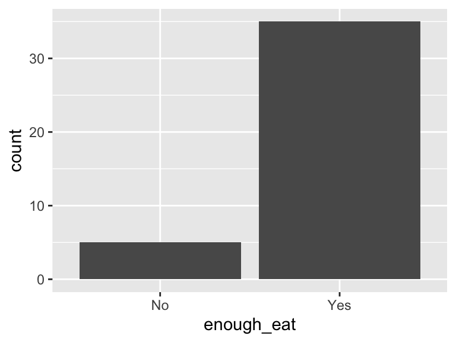

- Note that the following levels have at most five observations: "No".

## move_rural_urban

| Feature | Result |
| --- | --- |
| Variable type | character |
| Number of missing obs. | 0 (0 %) |
| Number of unique values | 2 |
| Mode | “Yes” |

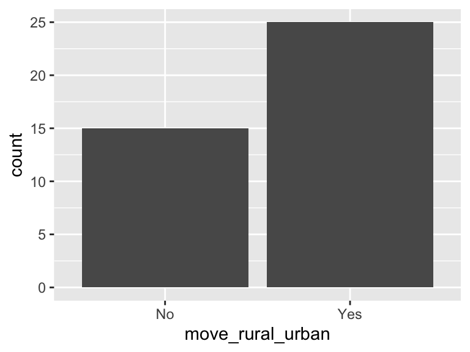

## contact_authority

| Feature | Result |
| --- | --- |
| Variable type | character |
| Number of missing obs. | 0 (0 %) |
| Number of unique values | 2 |
| Mode | “No” |

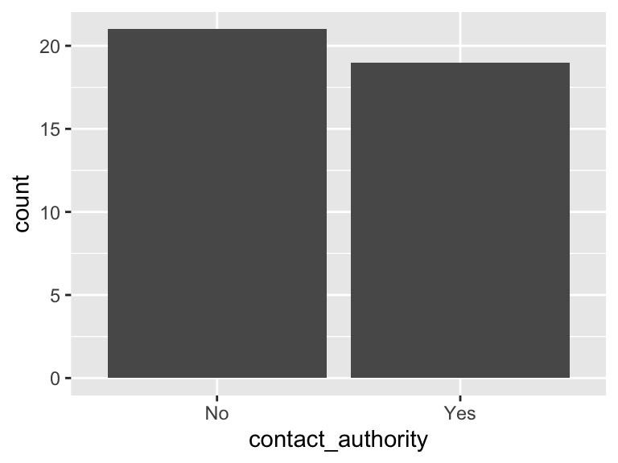

## demo_gender

| Feature | Result |
| --- | --- |
| Variable type | character |
| Number of missing obs. | 0 (0 %) |
| Number of unique values | 2 |
| Mode | “Male” |

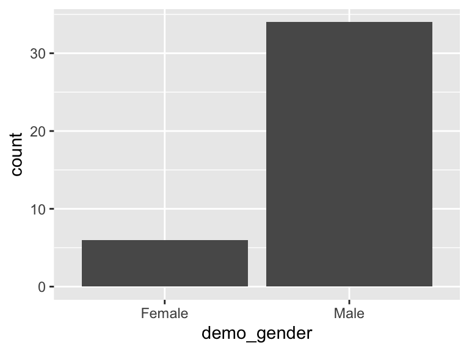

## demo_age

| Feature | Result |
| --- | --- |
| Variable type | character |
| Number of missing obs. | 0 (0 %) |
| Number of unique values | 23 |
| Mode | “35” |

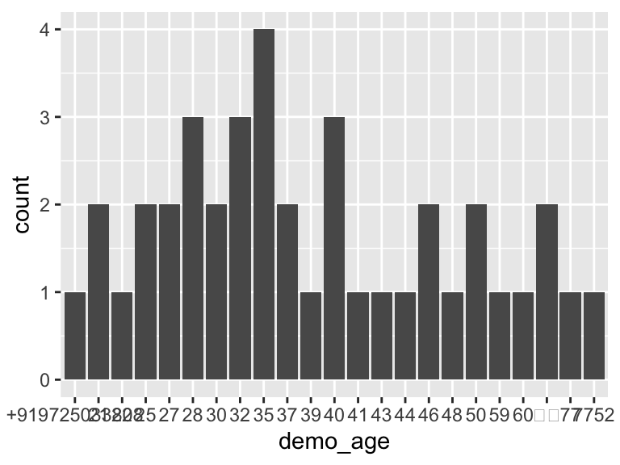

- Note that the following levels have at most five observations: "+919725033808", "21", "22", "25", "27", …, "59", "60", "૬૭", "77", "7752" (13 values omitted).

## demo_income

| Feature | Result |
| --- | --- |
| Variable type | character |
| Number of missing obs. | 0 (0 %) |
| Number of unique values | 26 |
| Mode | “10000” |

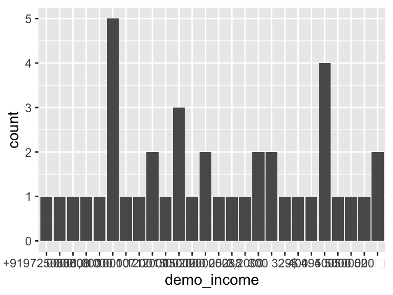

- Note that the following levels have at most five observations: "+919725033808", "0000", "00000", "1,000", "1000", …, "500", "5000", "50000", "520", "না" (16 values omitted).

## comp_phone1_try1

| Feature | Result |
| --- | --- |
| Variable type | character |
| Number of missing obs. | 0 (0 %) |
| Number of unique values | 33 |
| Mode | “+919725033808” |

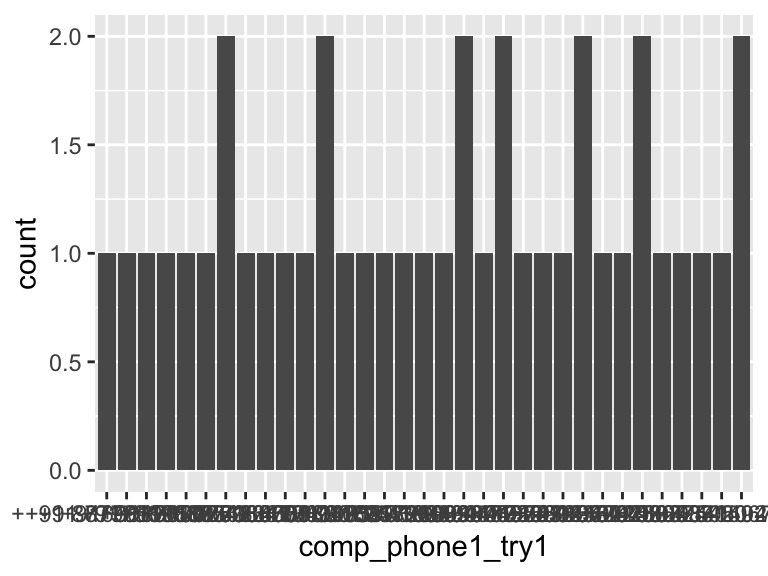

- Note that the following levels have at most five observations: "++91 8779619188", "+91 8779619188", "+916301303025", "+917567687041", "+918780176163", …, "9725604331", "9789774420", "9825370592", "9825950672", "9841404049" (23 values omitted).

## comp_phone1_try2

| Feature | Result |
| --- | --- |
| Variable type | character |
| Number of missing obs. | 0 (0 %) |
| Number of unique values | 32 |
| Mode | “+91 8779619188” |

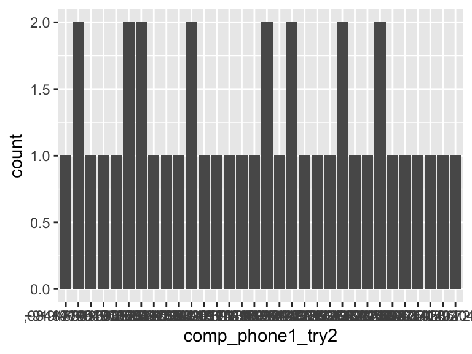

- Note that the following levels have at most five observations: ",9841404049", "+91 8779619188", "+916301303025", "+917567687041", "+919510742241", …, "9789774420", "9825370592", "9825958672", "9841404049", "હા" (22 values omitted).

## comp_phone2_try1

| Feature | Result |
| --- | --- |
| Variable type | character |
| Number of missing obs. | 36 (90 %) |
| Number of unique values | 4 |
| Mode | “+919619549079” |

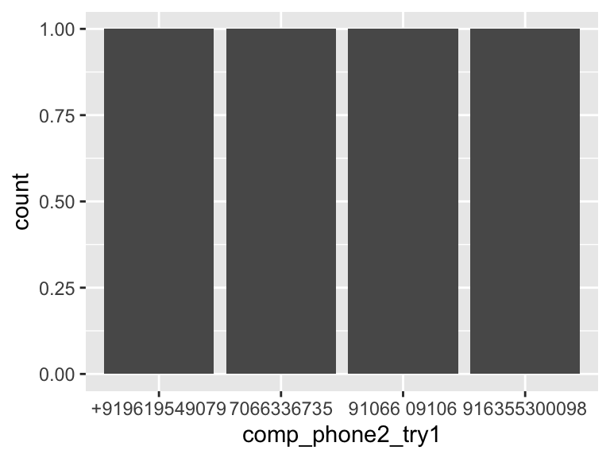

- Note that the following levels have at most five observations: "+919619549079", "7066336735", "91066 09106", "916355300098".

## comp_phone2_try2

| Feature | Result |
| --- | --- |
| Variable type | character |
| Number of missing obs. | 35 (87.5 %) |
| Number of unique values | 5 |
| Mode | “+919619549079” |

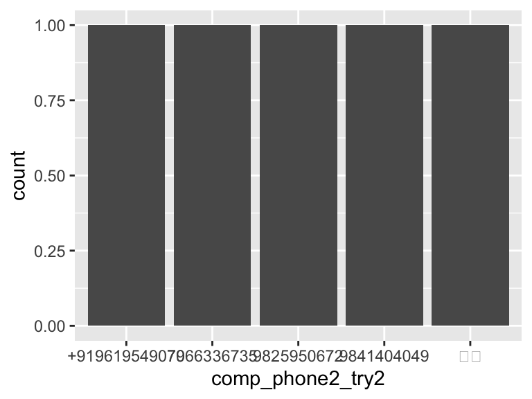

- Note that the following levels have at most five observations: "+919619549079", "7066336735", "9825950672", "9841404049", "હા".

## comp_phone3_try1

| Feature | Result |
| --- | --- |
| Variable type | character |
| Number of missing obs. | 38 (95 %) |
| Number of unique values | 2 |
| Mode | “6355300098” |

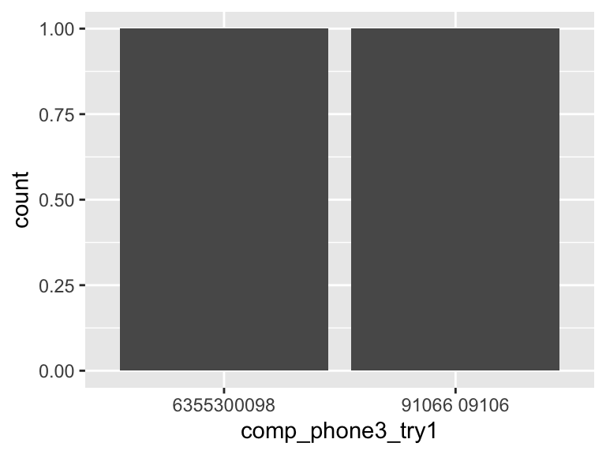

- Note that the following levels have at most five observations: "6355300098", "91066 09106".

## comp_phone3_try2

| Feature | Result |
| --- | --- |
| Variable type | character |
| Number of missing obs. | 38 (95 %) |
| Number of unique values | 2 |
| Mode | “91066 09106” |

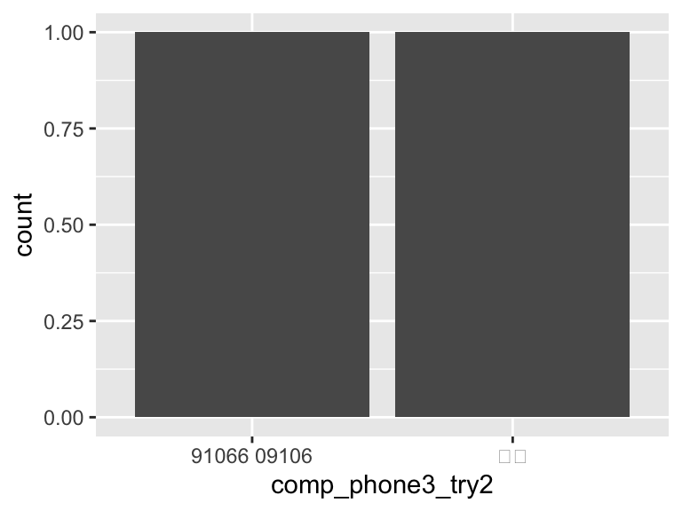

- Note that the following levels have at most five observations: "91066 09106", "હા".

## geo_lat

| Feature | Result |
| --- | --- |
| Variable type | character |
| Number of missing obs. | 17 (42.5 %) |
| Number of unique values | 20 |
| Mode | “18.9502044” |

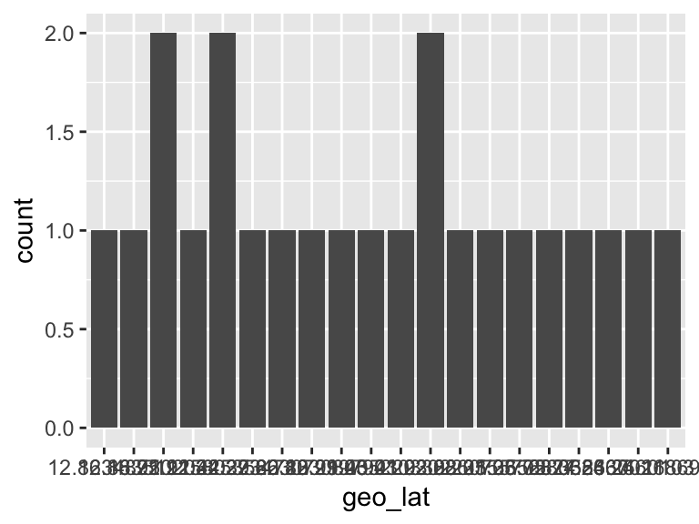

- Note that the following levels have at most five observations: "12.8634872", "12.8635111", "18.9502044", "21.9258029", "22.3253566", …, "23.0583356", "23.058337", "24.2560011", "24.2560103", "24.2686982" (10 values omitted).
- Note: The variable consists exclusively of numbers and takes a lot of different values. Is it perhaps a misclassified numeric variable?

## geo_lng

| Feature | Result |
| --- | --- |
| Variable type | character |
| Number of missing obs. | 17 (42.5 %) |
| Number of unique values | 20 |
| Mode | “70.8146097” |

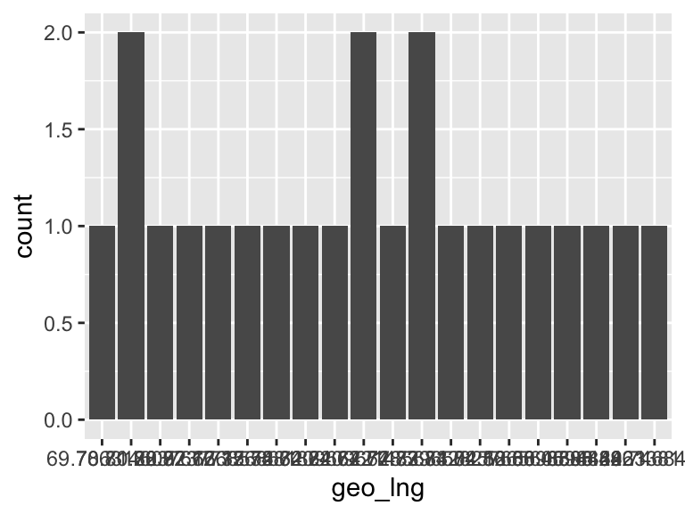

- Note that the following levels have at most five observations: "69.7863128", "70.8146097", "70.8237666", "70.8237735", "72.1768574", …, "80.0698595", "80.0698859", "88.442261", "88.4423381", "88.7468439" (10 values omitted).
- Note: The variable consists exclusively of numbers and takes a lot of different values. Is it perhaps a misclassified numeric variable?

## q_url

| Feature | Result |
| --- | --- |
| Variable type | character |
| Number of missing obs. | 0 (0 %) |
| Number of unique values | 31 |
| Mode | “https://ucsb.co1.qualtrics.com/jfe/form/SV_28ZOxlwZy4635uS?Q_Language=EN®ion=Andhra+Pradesh&gender=Male&age=30&fbclid=IwAR2njA2TywzwSwLyXeKIC_SqKHrcVA7icZhEFGJaG1K69UJ_srju46espjI_aem_Ac76nmsw7qht-AX… |

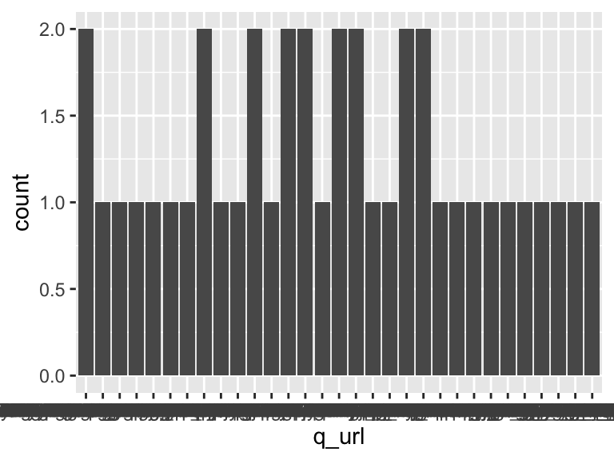

- Note that the following levels have at most five observations: "https://ucsb.co1.qualtrics.com/jfe/form/SV_28ZOxlwZy4635uS?Q_Language=EN®ion=Andhra+Pradesh&gender=Male&age=30&fbclid=IwAR2njA2TywzwSwLyXeKIC_SqKHrcVA7icZhEFGJaG1K69UJ_srju46espjI_aem_Ac76nmsw7qht-AXF6etgEFjTgW9Tniac8P_v57hjrcCACEN_Vlzv1vkfyDprp6SiO9Cz3K_ynls2Kw8EziUgBa1g\“, "https://ucsb.co1.qualtrics.com/jfe/form/SV_28ZOxlwZy4635uS?Q_Language=EN®ion=Gujar%C4%81t&gender=Male&age=18&fbclid=IwAR1jI4XRprKCWXPq5w-sZiW5DCd-tl2FjDsw0o-GhA9YihjFLC0zynv9HVw_aem_Ac91uqTtYX35w6lzHGoFQ_5HvmzkCElnJ3HlKGzo18iS-nmso22QK5x_dGxc7tNLZcIsDIRpAQF5zrV5o7Sol3Jr\”, "https://ucsb.co1.qualtrics.com/jfe/form/SV_28ZOxlwZy4635uS?Q_Language=EN®ion=Gujar%C4%81t&gender=Male&age=18&fbclid=IwAR37nNVoFDIGPIyVxDkl1rxr5uwYoOZYOz9lBkkcTONXRoqtMURwtuvveU8_aem_Afd763IAQsatFaenIg2qrAD8WnkiLJW7QwYUI4DLj4yagHW1DKYbeW6Yq4uwCJa-pDKqqlfk9ehyt9as0K-aBG8E\“, "https://ucsb.co1.qualtrics.com/jfe/form/SV_28ZOxlwZy4635uS?Q_Language=EN®ion=Gujar%C4%81t&gender=Male&age=18&fbclid=PAAablYjtNl5LPSBudYLuBNbQ0ujLHIb2OpJK95Upp5AuwWacbiDimDrQjgMM_aem_AVebwBrUp8S2NuPesDufsPUXv7zVvE-lICIckoylXBy22kIb-6a-nu3-58gaV4lF16FEZ5omtzeoSmaPCoHmrwhT\”, "https://ucsb.co1.qualtrics.com/jfe/form/SV_28ZOxlwZy4635uS?Q_Language=EN®ion=Gujar%C4%81t&gender=Male&age=18&fbclid=PAAabtnFLGTLL7LJgzVbdr5Pu4l_NrfbyL13lkXqruCCUKqugwOpxeGvvwwSg_aem_AUIurBLeBuQnJfJQ4XZ2cKyJW8B_AeDqfbmNVTSZGfvtyaMdvg9ggRkq7ekM0BT8jLZiNyobNCJqQSnxoVfXm4ml\“, …, "https://ucsb.co1.qualtrics.com/jfe/form/SV_28ZOxlwZy4635uS?Q_Language=EN®ion=Tamil+N%C4%81du&gender=Male&age=50&fbclid=IwAR3ojrIMImXp45U4DW-k0ExU4rsuesEbfdGm_e0LTlG3YLBqD0ELD9xgRtk_aem_AR_cVWohxiFlopjwKozn4YumDoXox2qlO1rk-mH2N_0edF7rS7ZtmNMIj0aadKkSUsZOzhbfAeRhh7w4lcl1vAMx\”, "https://ucsb.co1.qualtrics.com/jfe/form/SV_28ZOxlwZy4635uS?Q_Language=EN®ion=West+Bengal++%28second+half%29&gender=Male&age=18&fbclid=IwAR0gwiOv_dZ5KgouxgqRdubxkD4dDFIKEvG6ZrzgI9cAwuUEt3Zf-g6fauU_aem_AR_ImVDhmpCBv6aaRU1a4wTAq_SScSLee-4Ctl1y71VOeg-xewhzllFuRWsFLv-RxUuzK0_wCySBEm8f02dUBLwv\“, "https://ucsb.co1.qualtrics.com/jfe/form/SV_28ZOxlwZy4635uS?Q_Language=EN®ion=West+Bengal++%28second+half%29&gender=Male&age=18&fbclid=IwAR1KmnoSBHI0ziUQ4cno5hCUKnW0bqyV0SrPlNZh8nuBPHWiqGC0IEFXhXY_aem_AW6Ot3GMTPJEBFRqZVHdcqFAm9WxBDlfx5cJQMXSjMDQ8FD8-_XuRjgsDhs-iYQKubt9uQckJruV9o0Rjr-VKioA\”, "https://ucsb.co1.qualtrics.com/jfe/form/SV_28ZOxlwZy4635uS?Q_Language=EN®ion=West+Bengal++%28second+half%29&gender=Male&age=18&fbclid=IwAR2Q9-krpYU6mcFi69hBmErpnIWOsFdgS46yadO6qtNVqzmA98lC-YjzZxg_aem_AW7mvZtA1DFS7kAgDwhWPg693LQjZPbGm-_Pg8pKImTvrPaE4a0i9U0yivnrxunS53foDxuo-1qHmeNMz3du9g9N\“, "https://ucsb.co1.qualtrics.com/jfe/form/SV_28ZOxlwZy4635uS?Q_Language=EN®ion=West+Bengal++%28second+half%29&gender=Male&age=18&fbclid=IwAR2YM0fOg3e6Xg_sScIgAa1MxQlR6aKObeT55e-2Q8ncCoR0G46Hmtod384_aem_AR83kLKlUDi4E5RtBXR8cLoK7KefUwf04y_0NJrjH1TAm_MPOdYvhbBCwKiB7MetI2bEnaJnxDkFSkSVcFbTCVnr\” (21 values omitted).

## q_language

| Feature | Result |
| --- | --- |
| Variable type | character |
| Number of missing obs. | 0 (0 %) |
| Number of unique values | 7 |
| Mode | “EN” |

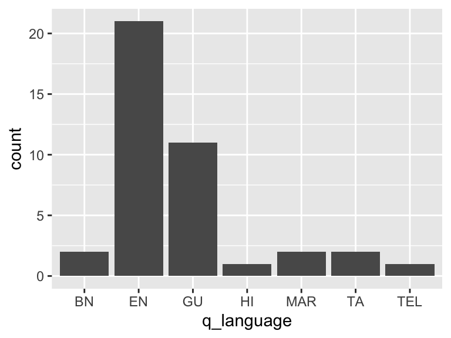

- Note that the following levels have at most five observations: "BN", "HI", "MAR", "TA", "TEL".

## gender

| Feature | Result |
| --- | --- |
| Variable type | character |
| Number of missing obs. | 0 (0 %) |
| Number of unique values | 2 |
| Mode | “Male” |

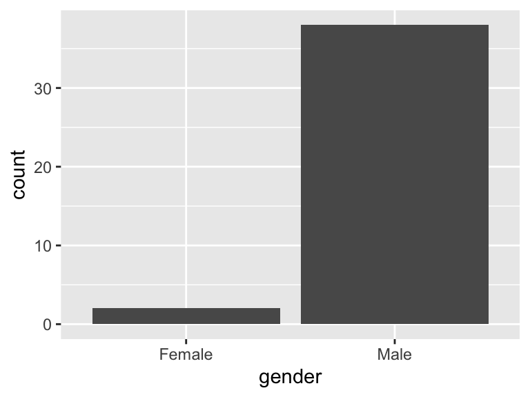

- Note that the following levels have at most five observations: "Female".

## region

| Feature | Result |
| --- | --- |
| Variable type | character |
| Number of missing obs. | 0 (0 %) |
| Number of unique values | 5 |
| Mode | “Gujarāt” |

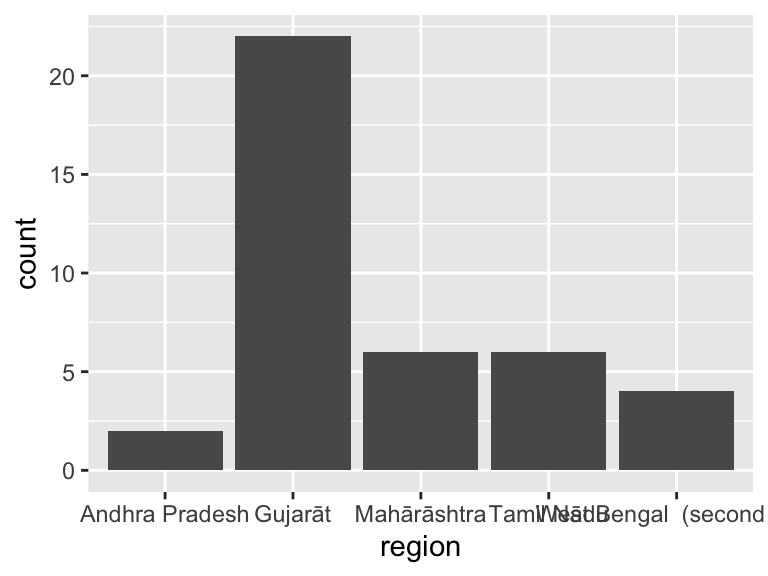

- Note that the following levels have at most five observations: "Andhra Pradesh", "West Bengal (second half)".

## age

| Feature | Result |
| --- | --- |
| Variable type | character |
| Number of missing obs. | 0 (0 %) |
| Number of unique values | 3 |
| Mode | “30” |

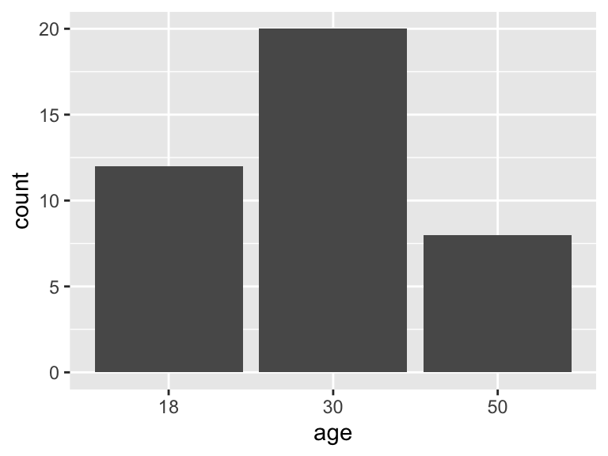

## geo_capability

- The variable only takes one value: "NA".

## geo_status

| Feature | Result |
| --- | --- |
| Variable type | character |
| Number of missing obs. | 0 (0 %) |
| Number of unique values | 3 |
| Mode | “3” |

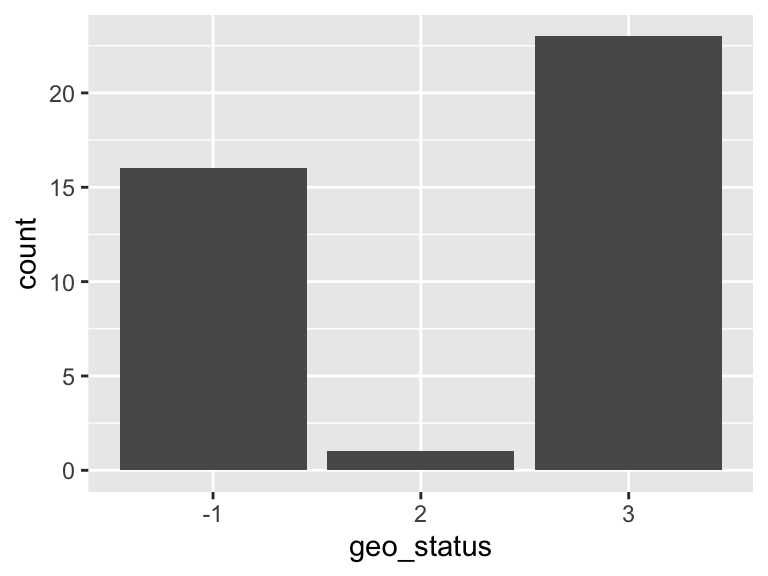

- Note that the following levels have at most five observations: "2".

## geo_error

- The variable only takes one (non-missing) value: "error". The variable contains 60 % missing observations.

## country

- The variable only takes one value: "NA".

## no_surverys_submitted

- The variable only takes one (non-missing) value: "2". The variable contains 0 % missing observations.

## income_brackets

| Feature | Result |
| --- | --- |
| Variable type | character |
| Number of missing obs. | 0 (0 %) |
| Number of unique values | 3 |
| Mode | “0% Tax Rate (Up to Rs. 3,00,000)” |

[figure not shown]

- Note that the following levels have at most five observations: "30% Tax Rate (Above Rs. 15,00,000)".

Report generation information:

- Created by: Sofia Ingersoll (username: `sofiaingersoll`).
- Report creation time: Sun Apr 21 2024 23:33:31
- Report was run from directory: `/Users/sofiaingersoll/2035/Adaptation_Observatory/response_analysis/dataMaid`
- dataMaid v1.4.1 [Pkg: 2021-10-08 from CRAN (R 4.3.0)]
- R version 4.3.2 (2023-10-31).
- Platform: aarch64-apple-darwin20 (64-bit)(America/Los_Angeles).
- Function call: `makeDataReport(data = dup_ip_ind, output = "html", replace = TRUE, reportTitle = "India Adaptation Observation Duplicate IP Address Survey Responses, Retrieval Date 15 April 2024.")`